# Distributing transmitters to maximize population-level representativeness in automated radio telemetry studies of animal movement | Movement Ecology | Full Text

[figure not shown]

Skip to main content

Advertisement

[Movement Ecology](https://movementecologyjournal.biomedcentral.com/)

- Research
- [Open access](https://www.springernature.com/gp/open-research/about/the-fundamentals-of-open-access-and-open-research)
- Published: 04 January 2023

# Distributing transmitters to maximize population-level representativeness in automated radio telemetry studies of animal movement

- Juliet S. Lamb,
- Pamela H. Loring &
- Peter W. C. Paton

[*Movement Ecology*](https://movementecologyjournal.biomedcentral.com/) **volume 11**, Article number: 1 (2023) Cite this article

- 3343 Accesses
- 3 Citations
- 1 Altmetric
- [Metrics details](https://movementecologyjournal.biomedcentral.com/articles/10.1186/s40462-022-00363-0/metrics)

## Abstract

Telemetry is a powerful and indispensable tool for evaluating wildlife movement and distribution patterns, particularly in systems where opportunities for direct observation are limited. However, the effort and expense required to track individuals often results in small sample sizes, which can lead to biased results if the sample of tracked individuals does not fully capture spatial, temporal, and individual variability within the target population. To better understand the influence of sampling design on results of automated radio telemetry studies, we conducted a retrospective power analysis of very high frequency (VHF) radio telemetry data from the Motus Wildlife Tracking System for two species of birds along the United States Atlantic coast: a shorebird, the piping plover (*Charadrius melodus*), and a nearshore seabird, the common tern (*Sterna hirundo*). We found that ~ 100–150 tracked individuals were required to identify 90% of locations known to be used by the tracked population, with 40–50 additional individuals required to include 95% of used locations. For any number of individuals, the percentage of stations included in the sample was higher for common terns than for piping plovers when tags were deployed within a single site and year. Percentages of stations included increased for piping plovers when birds were tagged over multiple sites and, to a lesser extent, years, and increased with average length of the tracking period. The probability that any given receiver station used by the population would be included in a subsample increased with the number of birds tracked, station proximity to a migratory stopover or staging site, number of receiving antennas per station, and percentage of the tracked population present. Our results provide general guidance for the number and distribution of tagged birds required to obtain representative VHF telemetry data, while also highlighting the importance of accounting for station network configuration and species-specific differences in behavior when designing automated radio telemetry studies to address specific research questions. Our results have broad applications to remotely track movements of small-bodied migratory wildlife in inaccessible habitats, including predicting and monitoring effects of offshore wind energy development.

## Background

Understanding wildlife habitat use and movement ecology often requires using transmitters to detect individuals in areas where opportunities for direct observation are limited. In cases where habitat characteristics or behavior of focal species present challenges to observing wildlife, individual tracking can be used to fill gaps in understanding of current distribution and predict responses to future conditions. Due to the high costs of tracking devices and welfare concerns related to the effects of capture and tagging, however, studies of animal movement often involve inferring population-level movement patterns from a small sample of individuals. Thus, it is crucial that the individuals selected for tracking effectively represent underlying individual, spatial, and interannual variation in movement patterns in the target population to avoid biasing the results [1].

Despite the importance of sampling design in telemetry studies, power analyses to inform study design remain relatively rare [2]. Sampling parameters are dictated by the cost, size, and technological limitations of tracking devices, rather than designed to maximize statistical power of the results to detect target patterns of movement [1, 2]. Nevertheless, accumulation of tracking data over time has created opportunities to synthesize existing data and assess how the number and distribution of sampled individuals affects detection of variation and population-level inferences [e.g., 3,4]. Such retrospective studies have generally focused on active transmitters that actively collect, store, and/or upload location data via satellite networks. Sampling considerations for passive transmitters, such as radio frequency identification (RFID), VHF, ultra high frequency (UHF), and acoustic units, whose detection depends on receiving antennas, have received comparatively less attention.

Most passive transmitters have several key advantages over GPS or satellite transmitters, including small sizes and costs. However, they also have unique sampling considerations that deserve attention. While detection of global positioning system (GPS) and ARGOS satellite transmitters depend on programming decisions such as sampling frequency, which affects the temporal resolution of data [5], their spatial coverage is global. In contrast, spatial coverage of locating passive transmitters is limited by the range of external receiving antennas to detect individuals passing through a focal area. Therefore, assessment of the effects of sampling design on distributional data derived from networks of receiving stations is required to identify factors affecting representativeness of tracked populations and inform future studies.

Given the challenges of directly observing wildlife movements in coastal and offshore marine environments, individual tracking is a vital component of understanding wildlife distributions in marine systems and predicting effects of future change. In North America, offshore wind energy development is nascent but rapidly advancing. Installations generating at least 16 gigawatts (GW) of energy are currently slated for development off the U.S. Atlantic coast, contributing to a national target of 30 GW by 2030 [6]. This ambitious development schedule has resulted in a need to rapidly acquire baseline data on wildlife presence and movements within and between offshore wind lease areas, as well as to develop robust monitoring protocols for measuring and determining the effects of offshore wind energy development on wildlife species of conservation concern [7]. Offshore wind stakeholders are recommending installation of fixed antenna arrays in offshore wind planning areas to detect passive transmitters on wildlife (i.e., both VHF and UHF transmitters), particularly small-bodied birds and bats, before, during, and after construction. However, the utility of antennas to detect movement patterns is highly dependent on the configuration of the antenna array, including the number and distribution of antenna stations and the heights of antennas relative to flight heights of target species [8]. Moreover, if an insufficient number of individuals are tagged with transmitters, or if the population selected for transmitter deployment does not represent the population using the location or route of interest, then use of specific sites (such as an offshore wind energy area) could be missed. To date, however, lack of information on the number and distribution of transmitters required for detection of baseline occupancy patterns has precluded the development of guidance for appropriate transmitter deployment.

To address this information gap, we tested the effect of sample size on the detection probability of free-flying VHF-tracked birds by a fixed array of coastal receiving stations along the mid-Atlantic coast of the United States in coordination with the Motus Wildlife Tracking System, an international radio telemetry network that automatically detects and identifies organisms with VHF transmitters and stores detection data for subsequent download and analysis [9]. Few receiving stations are currently deployed in the offshore environment; however, existing data from onshore stations can be used as a starting point to assess effects of number and distribution of transmitters on detection patterns and begin developing sampling guidelines. We focused our analysis on two representative coastal species with different migratory patterns and habitat requirements: a shorebird (piping plover *Charadris melodius*) and a nearshore seabird (common tern *Sterna hirundo*). Our objectives were to (1) subsample existing data to determine the number of tagged individuals required to represent population-level occupancy patterns for each species across Motus stations; (2) assess whether distributing transmitters among different combinations of tagging sites and years improved probability of detecting occupied sites; and (3) evaluate how the distance of receiving stations from the tagging site affects detection probability across sample sizes, tag distributions, and species.

## Methods

### Data collection

#### Study species

Piping plovers are small-bodied (43–63 g) migratory shorebirds. On the Atlantic coast of North America, where the species is federally listed as Threatened, their breeding range extends from the Canadian Maritimes to North Carolina, and their wintering range occurs from the mid-Atlantic United States to the Gulf of Mexico and the Caribbean [10]. In coastal areas, piping plovers typically nest on open sandy beaches and forage on a variety of invertebrates along the shoreline and intertidal zone [10].

Common Terns are globally-distributed, mid-sized (110–145 g) seabirds that breed throughout the Northern Hemisphere and winter along tropical and subtropical coasts [11]. Along the northern Atlantic coast of North America, Common Terns nest colonially on islands and barrier beaches from Newfoundland and Labrador, Canada to South Carolina, USA [11]. During their northerly migration, common terns have been observed flying over open ocean more than 50 km off the coasts of Virginia and Massachusetts [12,13,14].

#### Capture and tagging

We tracked movements of piping plovers and common terns using uniquely coded VHF transmitters (“nanotags”, Lotek Wireless, Ontario, Canada) at focal breeding sites in southern New England. We were interested in tracking breeding-season and fall migratory departure movements of these species along the U.S. Atlantic Coast and adjacent OCS waters from Cape Cod, Massachusetts in the north to Back Bay, Virginia to the south. As of May 2022, this area contains 25 BOEM Renewable Energy Commercial Lease Areas and one Research Lease Area [6].

We tagged piping plovers between 2015 and 2017 in two principal breeding locations: southeastern Massachusetts (Monomoy Island and South Beach), and the southern coast of Rhode Island (Fig. 1). Monomoy and South Beach account for ~ 9% of the Massachusetts population of piping plovers, while focal sites in Rhode Island supported at least one third of nesting pairs monitored in the state [14]. From 9 May through 27 June, we captured adult plovers at their nest sites during the egg incubation period using funnel traps. A small number (*n* = 10) of piping plovers were tagged in the Bahamas during March 2017 with the aim of tracking northbound migratory movements. Tagging sites were in the northwestern Bahamas on North Andros (Young Sound and Kamalame Cay) and the Joulter Cays. Plovers were captured in diurnal foraging areas using drop nets. All piping plovers were fitted with Lotek NTQB-4-2 (1.1 g; 12 × 8 × 8 mm; < 3% body mass) nanotags with 16.5-cm antennas. Tags were attached by clipping a small area of feathers from the interscapular region and gluing the tag to the feather stubble and skin with a cyanoacrylate gel adhesive [8].

**Fig. 1**

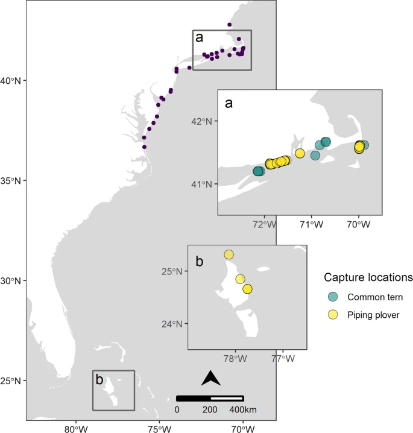

Motus antenna locations along the Atlantic coast of North America (black dots) that detected either piping plovers or common terns in this study and were continuously operational between 2014 and 2017. Inset maps show relative locations of **a** New England tagging sites for piping plovers (yellow; 2015–2017) and common terns (teal; 2014–2017); and **b** Bahamas tagging locations for piping plovers (yellow; 2017 only)

[Full size image](https://movementecologyjournal.biomedcentral.com/articles/10.1186/s40462-022-00363-0/figures/1)

Between 2014 and 2017, we tagged common terns at several breeding colonies across the same southern New England range (Fig. 1): at Great Gull Island, NY, in eastern Long Island Sound; at Monomoy Island (2014); and at three colonies in Buzzard’s Bay, Massachusetts (Bird, Ram, and Penikese Islands; 2016–2017). From 9 June to 12 July, staff at nesting colonies used walk-in treadle traps to capture adult common terns at their nests, within approximately 1–5 days of their eggs hatching. Common terns were fitted with waterproofed Lotek NTQB-4-2 nanotags with 1-mm tubes at the front and back of the transmitter, bringing the total tag weight to 1.5 g. The transmitter and attachment materials weighed < 2% of the body mass of tagged terns. We attached nanotags to the dorsal inter-scapular region using cyanoacrylate adhesive and two sutures (Prolene: 45-cm length, 4.0, BB taper point needle, catalog # 8581H) inserted subcutaneously and secured to the end-tubes of the transmitter [14].

All transmitters were programmed to continuously transmit on a shared frequency of 166.380 MHz from activation through the end of battery life. Times between transmissions (burst intervals) were specific to each transmitter and ranged from 4 to 6 s. All transmitters were uniquely identifiable on the shared frequency using a combination of an encoded tag ID and known burst intervals in coordination with the Motus Wildlife Tracking System [9]. The expected life of the NTQB-4-2 nanotags ranged from 146 days (4 s burst interval) to 187 days (6 s burst interval). For each tracked individual, we tallied the total number of transmissions received and calculated the duration of transmission by subtracting the deployment date from the date of last transmission received.

#### Automated telemetry stations

We obtained signals of tagged birds using an array of land-based automated radio telemetry stations (i.e., stations that automatically scan for organisms with uniquely-coded VHF transmitters and record detections; hereafter, stations) throughout the study area (Additional file 1: Table S1). Typical station specifications consisted of a 12.2-m tall radio antenna mast supporting 4–6, 9-element (3.3 m) Yagi antennas mounted in a radial configuration at 60-degree intervals. Antennas were connected to ports on a receiving unit (Lotek SRX-600 or 800, Lotek Wireless, Ontario, Canada) via coaxial cable (TWS-200). Each receiving station was operated 24 h per day using one 140-W solar panel and two 12-V deep- cycle batteries. When tagged birds were within detection range, the receivers automatically recorded transmitter ID number, date, time stamp, antenna (defined by monitoring station and bearing), and signal strength value of each detection. All raw data and metadata were uploaded to the Motus Wildlife Tracking System for processing [9]. We used the ‘motus’ package in R to download and filter detection data using default criteria [15].

### Data analysis

#### Bootstrapped inclusion values

We began by using detection radius estimates and active dates provided on the Motus website [16] to combine any receiving stations that were placed in identical locations and eliminate any stations or station groups that were not active during the full study period. We then used a bootstrapping approach to assess how well different subsamples of the population represented occurrence patterns of un-sampled individuals [17, 18]. This involved repeatedly selecting random subsamples of *n* individuals from the overall sample *N* and calculating the inclusion value. We defined the inclusion value as the proportion of stations used by the subsampled population that were also used by the remaining individuals not included in the subsample. We conducted all analyses in R [19].

For each sample size *n* up to a maximum of *N* − 1, we repeated the process 50 times and calculated the mean (µ) and standard deviation of the inclusion value for a given sample size (*I*<sub>*n*</sub>) over the 50 random subsamples. We then fitted a non-linear model to the means of the bootstrapped samples of the form µ*I*<sub>*n*</sub> = a*n*/1 + b*n*, where a and b represent numeric coefficients. We estimated parameter values via non-linear least squares estimation, with starting values of a = 1 and b = 0.1. We used the modeled relationship between the inclusion value and sample size to identify sample sizes required to achieve inclusion at three different levels—80%, 90%, and 95%—that approximately correspond to confidence intervals commonly used to detect significant effects. After fitting a non-linear function to the data, we calculated the representativeness for any given sample size (*R*<sub>*n*</sub>) by dividing the projected inclusion value for that subsample (*I*<sub>*n*</sub>) by the asymptote of the fitted non-linear function (*I*<sub>*max*</sub>): *R*<sub>*n*</sub> = *I*<sub>*n*</sub>/*I*<sub>*max*</sub>. We also calculated the representativeness of each capture site as the asymptote for that capture site alone, divided by the asymptote across the full population (*R(capture site)* = *I*<sub>*max*</sub>*(capture site)*/*I*<sub>*max*</sub>*(population)*).

We calculated representativeness across different combinations of tagging sites and years by constraining our random draws to specific number of tagging sites (1–2) or years (1–3), then comparing the inclusion values from each combination of sites and years with the asymptotic inclusion value *I*<sub>*max*</sub> for the overall sample. Since the Bahamas were only sampled in one year for piping plovers, we removed individuals captured at this site from analysis of site-year effects. Similarly, since common terns were only captured at one site (GGI) in 2015, we removed this year from analysis of site-year effects but retained all years with two distinct capture sites.

Finally, for piping plovers, we also assessed the detection probabilities of detecting at individual receiving stations by calculating the probability that each used station would be included in the subset of stations used by a bootstrapped subsample of *n* individuals (*T*<sub>*n*</sub>). Since common tern sampling was designed to detect individuals during post-breeding staging but not during migration [20], we expected station characteristics to play a limited role in station-specific detection rates for this species; we therefore did not assess this metric for common terns.

#### Modeling

We fit generalized additive models (GAMs) with residual maximum likelihood [21] using the mgcv R package [22] to determine the effects of dividing any given sample size across multiple tagging sites or years on both inclusion values and their variability. We modeled either the mean or the standard deviation of the raw bootstrapped inclusion values (response) as a function of number of transmitters (smoothed predictor), number of tagging sites (categorical predictor), number of years (categorical predictor), average duration of transmission (i.e., number of days between tag deployment and last detection; smoothed predictor), and average number of detections per individual (smoothed predictor). We identified a predictor as significant if its 95% confidence interval (CI) did not overlap zero. To assess factors affecting inclusion probabilities for used stations, we modeled means and standard deviations of station-specific inclusion probabilities *T*<sub>*n*</sub> as a function of number of transmitters, distance to tagging site, number of receiving antennas, antenna altitude, and number of detections at the station (smoothed predictors).